# Checkpoint1

Carlos Interaminense

July 25, 2017

```r
library(plotly)
library(ggplot2)
library(GGally)
library(dplyr)
library(tidyverse)
library(resample) # <-- Para bootstrap!
library(lubridate)
theme_set(theme_bw())
```

# Dados de commits no GitHub

Usaremos neste relatório uma amostra dos dados do GitHub, que correspondem a quantidade de usuários que editaram arquivos com extensão em comum (arquivos referentes a linguagens de programação) em em um determindado dia. Sabemos que o GitHub dispõe de uma quantidade enorme de dados, chutaria algo como *Terabytes*, portanto, neste relatório vamos considerar apenas uma amostra desses dados referentes aos anos de 2016 e 2017 de arquivos com algumas extensões que são referentes as liguagens de programação (ex: java, js, py, entre outras).

## Descritivo dos dados

```r
#Carregando os dados
dados = read_csv("./github-users-commiting-filetypes.csv");
```

É esperado que:  
- os dias do mês estajam entre 1-31;  
- os meses estejam entre 1-12;  
- a quantidade de usuários não seja negativa ( < 0 )

A partir da tabela a seguir, podemos verificar que os dados estão dentro dos intervalos esperados.

```r
min_month_day = min(dados$month_day);
max_month_day = max(dados$month_day);
min_month = min(dados$the_month);
max_month = max(dados$the_month);
min_users = min(dados$users);
max_users = max(dados$users);


m  <- matrix(c(min_month_day, max_month_day, min_month, max_month, min_users, max_users), ncol=2,byrow = TRUE);
colnames(m) <- c("mínimo", "máximo")
rownames(m) <- c("Dias do mês", "Mês", "#Usuários")
m <- as.table(m)
m
```

```
##             mínimo máximo
## Dias do mês      1     31
## Mês              1     12
## #Usuários      501  10279
```

Em que, na Tabela acima, #Usuários é a quantidade de usuários.

Para termos uma noção da distribuição dos valores dos usuários, usaremos o boxplot abaixo:

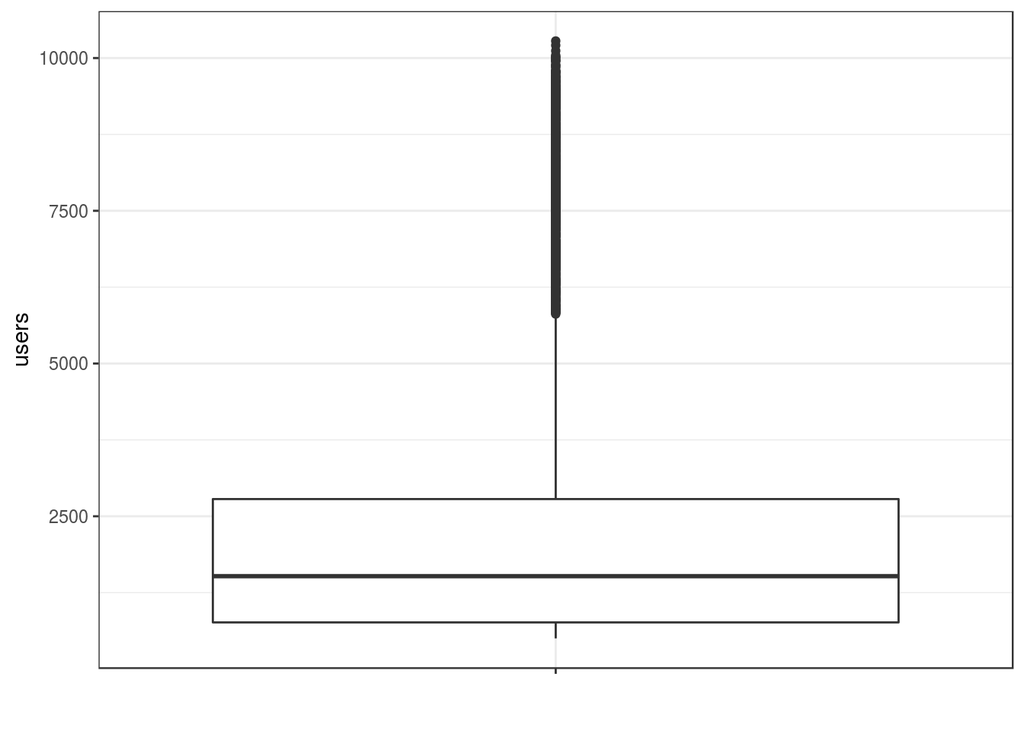

```r
dados %>%
  ggplot(aes(x = "", y = users)) +
  geom_boxplot() +
  xlab("")
```

O gráfico acima deixa claro que existem valores considerados *outliers* (sequência de pontos da cor preta na parte superior do boxplot). Uma forma de lidar com esses *outliers* é usar a mediana dos valores, já que a mesma não é influenciada por valores extremos.

Agora podemos prosseguir com o relatório. Vou escolher duas linguagens de programação e responder duas perguntas. As linguagens que escolhi foram: PYTHON e C++.

```r
dados_python <- dados %>%
  filter(file_extension == "py")

dados_cpp <- dados %>%
  filter(file_extension == "cpp")
```

### Pergunta 1: Para cada uma delas, há uma diferença significativa na sua popularidade durante a semana e durante o fim de semana? Essa diferença é grande?

Para responder esta pergunta, é preciso criar uma nova váriável no conjunto dos dados das linguagens escolhidas, para conseguirmos saber o dia da semana de cada dado e separar os dois conjuntos de dados (finais de semana e dias de semana).

```r
  dados_cpp$date <- paste(dados_cpp$month_day, dados_cpp$the_month, dados_cpp$the_year, sep = "-")
  dados_cpp  <- dados_cpp %>%
    mutate(weekday = (weekdays(as.Date(date,'%d-%m-%Y')) == 'sábado' | weekdays(as.Date(date,'%d-%m-%Y')) == 'domingo' )   )

  dados_python$date <- paste(dados_python$month_day, dados_python$the_month, dados_python$the_year, sep = "-")
  dados_python  <- dados_python %>%
    mutate(weekday = (weekdays(as.Date(date,'%d-%m-%Y')) == 'sábado' | weekdays(as.Date(date,'%d-%m-%Y')) == 'domingo' )   )
```

```r
b1  = dados_cpp %>%
  filter(weekday == TRUE) %>%
  bootstrap(median(users))

median_cpp.weekday = b1 %>%
  CI.percentile(props = c(.025, .975))

b2  = dados_cpp %>%
  filter(weekday == FALSE) %>%
  bootstrap(median(users))

median_cpp.fds = b2 %>%
  CI.percentile(props = c(.025, .975))

df.medians = data.frame(rbind(median_cpp.weekday, median_cpp.fds))
```

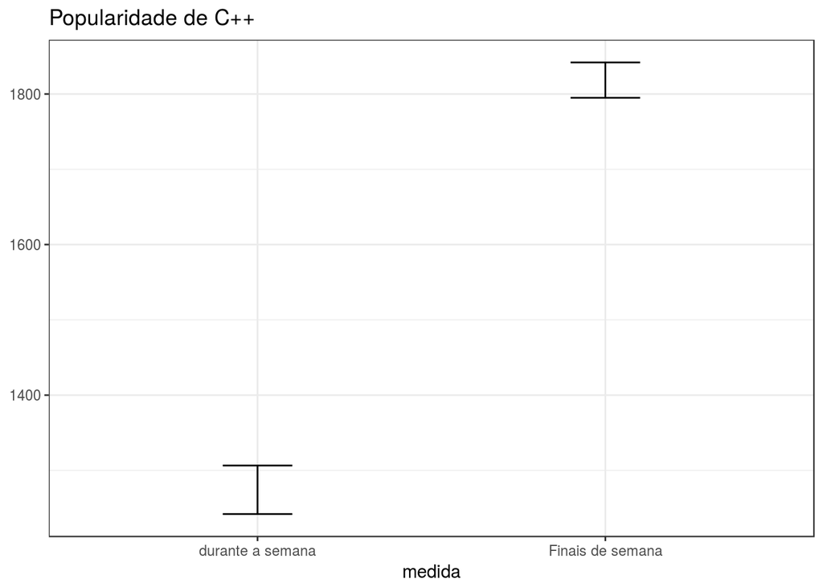

```r
df.medians$medida= c("durante a semana", "Finais de semana")

df.medians %>%
  ggplot(aes(x = medida, ymin = X2.5., ymax = X97.5.)) +
  geom_errorbar(width = .2) +
  ggtitle("Popularidade de C++")
```

Similarmente com o que fizemos com a linguagem de programação C++, vamos fazer para PYTHON também usando a técnica de bootstrap.

```r
b1  = dados_python %>%
  filter(weekday == TRUE) %>%
  bootstrap(median(users))

median_cpp.weekday = b1 %>%
  CI.percentile(props = c(.025, .975))

b2  = dados_python %>%
  filter(weekday == FALSE) %>%
  bootstrap(median(users))

median_cpp.fds = b2 %>%
  CI.percentile(props = c(.025, .975))

df.medians = data.frame(rbind(median_cpp.weekday, median_cpp.fds))
```

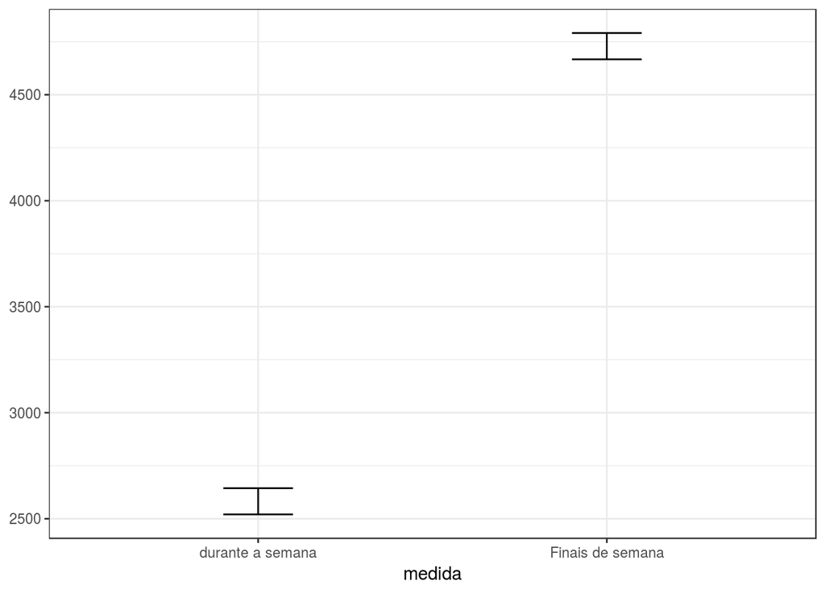

```r
df.medians$medida= c("durante a semana", "Finais de semana")

df.medians %>%
  ggplot(aes(x = medida, ymin = X2.5., ymax = X97.5.)) +
  geom_errorbar(width = .2)
```

### Pergunta 2): Existe uma diferença significativa entre as duas linguagens na sua variação de popularidade nos finais de semana?

Agora, vamos reaizar um comparativo similar ao anterior mas consideraremos as duas linguagens de uma só vez, analisando sua popularidade nos finais de semana, apenas.

```r
b1  = dados_python %>%
  filter(weekday == FALSE) %>%
  bootstrap(median(users))

median.python_fds = b1 %>%
  CI.percentile(props = c(.025, .975))

b2  = dados_cpp %>%
  filter(weekday == FALSE) %>%
  bootstrap(median(users))

median.cpp_fds = b2 %>%
  CI.percentile(props = c(.025, .975))

df.medians = data.frame(rbind(median.python_fds, median.cpp_fds))
```

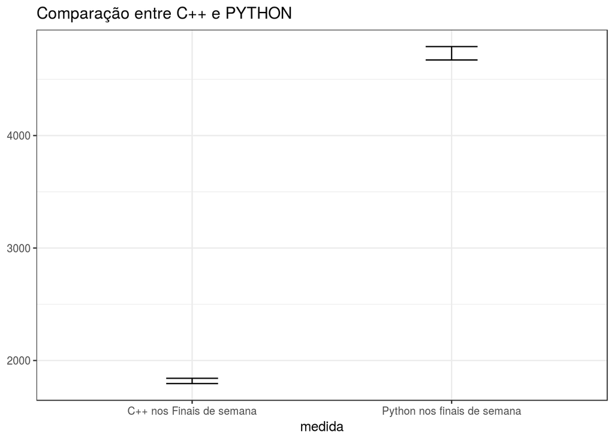

```r
df.medians$medida= c("Python nos finais de semana", "C++ nos Finais de semana")

df.medians %>%
  ggplot(aes(x = medida, ymin = X2.5., ymax = X97.5.)) +
  geom_errorbar(width = .2) +
  ggtitle("Comparação entre C++ e PYTHON")
```